# Detekcja mechanizmu selekcji

# Wstęp

Potrzebujemy następuących pakietów

```r
library(vcdExtra)
library(gmodels) ## ładne tabele
library(sjPlot) ## ładne tabele w HTMLu
library(tidyverse)
#install.packages("http://smarterpoland.pl/materialy/KTr/CressieReadTest_1.0.tar.gz",
#                 repos = NULL, type = "source")
library(CressieReadTest) ## source http://smarterpoland.pl/materialy/KTr/cr2.pdf
```

```r
load('../data/diagnoza2015.rdata')
diagnoza2015
```

| id_gosp | id_osoba | woj | klm | plec | internet | wyksz | nauka_lata | czy_praca | czy_pelny_etat | czy_rej_pup | dzieci | wiek |
| --- | --- | --- | --- | --- | --- | --- | --- | --- | --- | --- | --- | --- |
| 2 | 3 | 2 | 6 | 2 | 1 | 50 | 10 | 1 | 1 | 2 | 1 | 53 |
| 12 | 1 | 2 | 6 | 1 | 1 | 50 | 11 | 1 | 1 | 2 | 1 | 50 |
| 12 | 7 | 2 | 6 | 1 | 1 | 30 | 13 | 1 | 1 | 2 | 1 | 35 |
| 12 | 2 | 2 | 6 | 2 | 1 | 50 | 11 | 1 | 2 | 2 | 1 | 50 |
| 12 | 4 | 2 | 6 | 2 | 1 | 30 | 12 | 2 | 0 | 2 | 1 | 25 |
| 12 | 5 | 2 | 6 | 2 | 1 | 40 | 9 | 2 | 0 | 2 | 0 | 19 |
| 33 | 1 | 2 | 6 | 1 | 2 | 60 | 7 | 2 | 0 | 2 | 0 | 63 |
| 33 | 2 | 2 | 6 | 2 | 2 | 60 | 7 | 2 | 0 | 2 | 1 | 59 |
| 56 | 1 | 2 | 1 | 1 | 1 | 40 | 12 | 1 | 1 | 2 | 1 | 56 |
| 56 | 2 | 2 | 1 | 2 | 2 | 40 | 12 | 2 | 0 | 2 | 1 | 56 |

[output cut: 190 more lines]

Naszym celem jest oszacowanie poniższego modelu, gdzie zmienna Interent przyjmuje dwie wartości $\{0,1\}$

$$P(Internet = 1 | \boldsymbol{X})$$

oraz kolejny, gdzie zmienna Odpowiedź również przyjmuje dwie wartości $\{0,1\}$:

$$P(Odpowiedź = 1 | \boldsymbol{X}, Internet = 1)$$

# Badanie zależności między zmienną jakościową, a innymi zmiennymi

## Tabele

```r
structable(internet ~ klm, diagnoza2015)
```

```
    internet    1    2
klm
1             926  100
2             995  135
3             782  133
4            2012  523
5            1366  416
6            5244 2681
```

```r
CrossTable(diagnoza2015$internet,diagnoza2015$klm)
```

```
   Cell Contents
|-------------------------|
|                       N |
| Chi-square contribution |
|           N / Row Total |
|           N / Col Total |
|         N / Table Total |
|-------------------------|


Total Observations in Table:  15313


                      | diagnoza2015$klm
diagnoza2015$internet |         1 |         2 |         3 |         4 |         5 |         6 | Row Total |
----------------------|-----------|-----------|-----------|-----------|-----------|-----------|-----------|
                    1 |       926 |       995 |       782 |      2012 |      1366 |      5244 |     11325 |
                      |    36.844 |    30.361 |    16.384 |    10.040 |     1.755 |    64.968 |           |
                      |     0.082 |     0.088 |     0.069 |     0.178 |     0.121 |     0.463 |     0.740 |
                      |     0.903 |     0.881 |     0.855 |     0.794 |     0.767 |     0.662 |           |
                      |     0.060 |     0.065 |     0.051 |     0.131 |     0.089 |     0.342 |           |
----------------------|-----------|-----------|-----------|-----------|-----------|-----------|-----------|
                    2 |       100 |       135 |       133 |       523 |       416 |      2681 |      3988 |
                      |   104.628 |    86.218 |    46.527 |    28.511 |     4.983 |   184.493 |           |
                      |     0.025 |     0.034 |     0.033 |     0.131 |     0.104 |     0.672 |     0.260 |
                      |     0.097 |     0.119 |     0.145 |     0.206 |     0.233 |     0.338 |           |
                      |     0.007 |     0.009 |     0.009 |     0.034 |     0.027 |     0.175 |           |
----------------------|-----------|-----------|-----------|-----------|-----------|-----------|-----------|
         Column Total |      1026 |      1130 |       915 |      2535 |      1782 |      7925 |     15313 |
                      |     0.067 |     0.074 |     0.060 |     0.166 |     0.116 |     0.518 |           |
----------------------|-----------|-----------|-----------|-----------|-----------|-----------|-----------|
```

```r
sjt.xtab(diagnoza2015$klm,diagnoza2015$internet,show.na = T)
```

| Symbol klasy miejscowości zamieszkania | Czy korzysta z interentu? |  |  | Total |  |
| --- | --- | --- | --- | --- | --- |
|  | BD/ND/FALA | TAK | NIE |  |  |
| BD/ND/FALA | 0 | 0 | 0 |  | 0 |
| miasta o liczbie mieszkańców 500 tys. i więcej | 0 | 926 | 100 | 1026 |  |
| miasta o liczbie mieszkańców 200-500 tys. | 0 | 995 | 135 | 1130 |  |
| miasta o liczbie mieszkańców 100-200 tys. | 0 | 782 | 133 | 915 |  |
| miasta o liczbie mieszkańców 20-100 tys. | 0 | 2012 | 523 | 2535 |  |
| miasta o liczbie mieszkańców poniżej 20 tys. | 0 | 1366 | 416 | 1782 |  |
| wieś | 0 | 5244 | 2681 | 7925 |  |
| Total | 0 | 11325 | 3988 | 15313 |  |

## Wizualizacja danych

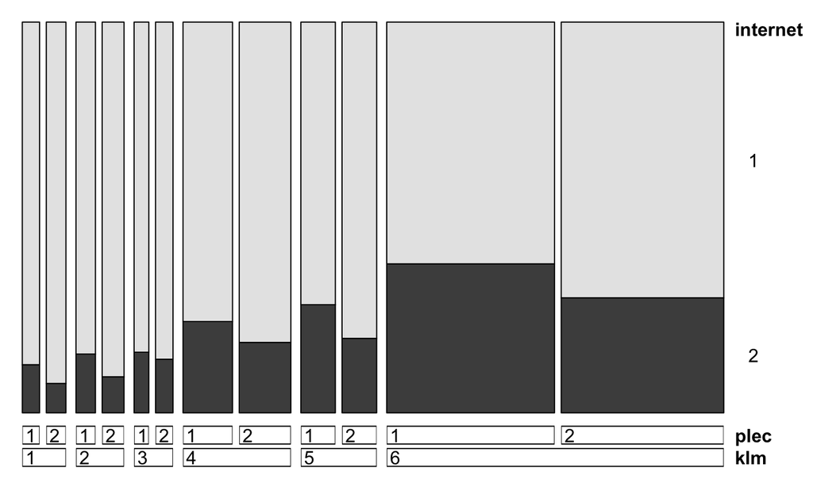

```r
doubledecker(internet ~ klm + plec, diagnoza2015)
```

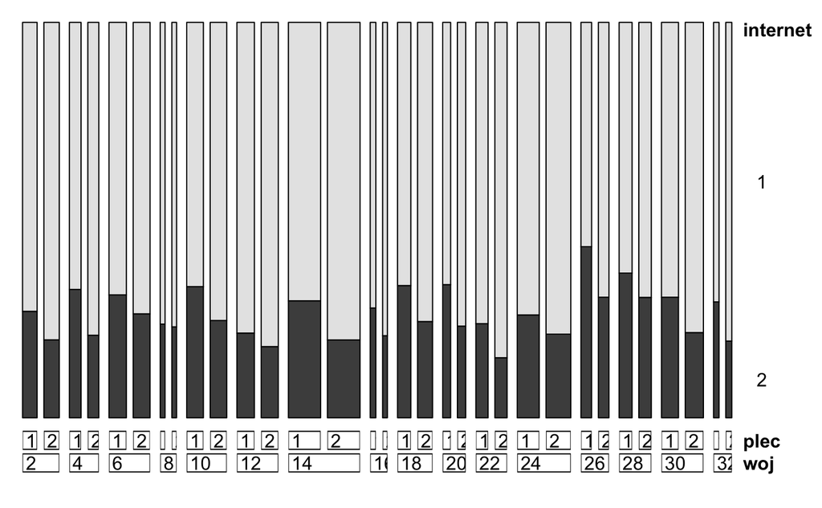

```r
doubledecker(internet ~ woj + plec, diagnoza2015)
```

## Statystyki zależności między dwiema zmiennymi jakościowymi

Aby zbadać zależność między dwoma i więcej zmiennymi możemy wykorzystać następujące testy:

- Test proporcji (ma sens w tabeli $2 \times 2$),
- Testy oparte na statystyce $\chi^2$:
  - Test niezależności $\chi^2$,
  - Test niezależności $\chi^2$ z poprawką Yates’a (dla małych prób, kwestia przybliżenia rozkładu dwumianowego rozkładem $\chi^2$),
  - statystyka największej wiarygodności $L^2$ (badamy równość proporcji),
  - statystyka Cressie-Read’a (CR),
  - test (Cochrana-)Mantel-Haenszel $\chi^2$ – stosujemy dla 3 zmiennych: zakładamy, że dwie zmienne są warunkowo niezależne, w warstwach utworzonych przez trzecią zmienną.
- (Dokładny) test Fishera (zwykle dla tabel $2 \times 2$ i małych prób),
- Test Mantela-Haenszel’a $\chi^2$ – tylko jeżeli dwie zmienne są na skali porządkowej

Miary zależności:

- współczynnik Yule’a – dwie zmienne, mające porządek (tak, nie) i traktujemy symetryczne (zmiana porządku w tabeli nie wpływa na statystykę)
- współczynnik C Pearsona – dwie zmienne, nie mają porządku, traktujemy symetrycznie (odnosi się do tej i poniższych dwóch)
- współczynnik V Cramera,
- współczynnik T Czupurowa,
- Goodman-Kruskal $\gamma$ – dla zmiennych na skali porządkowej (`vcdExtra::GKgamma`)

Więcej na – http://node101.psych.cornell.edu/Darlington/crosstab/TABLE0.HTM

## Statystyka $D^2$ Cressie-Read’a

$$D^2=\frac{2}{\lambda(\lambda+1)}\sum_{i=1}^{r}\sum_{j=1}^{c} O_{ij}\left[\left(\frac{O_{ij}}{E_{ij}}\right)^{\lambda}-1\right]$$

gdzie:

- $O_{ij}$ – empiryczna liczebność $i$-tego wiersza oraz $j$-tej kolumny,
- $E_{ij}$ – oczekiwana liczebność $i$-tego wiersza oraz $j$-tej kolumny,
- $r$ – liczba wierszy,
- $c$ – liczba kolumn.

Dobierając odpowiednią wartość parametru $\lambda$możemy uzyskać wyniki dla kilku różnych testów niezależności opartych na statystyce $\chi^2$.

- $\chi^2$Pearsona otrzymamy gdy $\lambda=1$,
- statystykę Neymana dla $\lambda=-2$ która jest modyfikacją testu $\chi^2$ Pearsona.
- statystykę testu $G^2$ największej wiarygodności uzyskamy dla parametru $\lambda\rightarrow 0$,
- statystkę Kullback-Leibler otrzymamy gdy $\lambda\rightarrow -1$,
- statystyka Freemana i Tukeya otrzymamy dla $\lambda=-\frac{1}{2}$.

Na bazie statystyki $\chi^2$ można obliczyć kilka współczynników, które określają siłę związku badanych zmiennych.

- współczynnik Yule’a – ma zastosowanie dla tabel o wymiarach $2\times 2$ oraz $\phi\in\langle -1;1\rangle$:

$$\phi=\sqrt{\frac{\chi^2}{n}}$$

- współczynnik Pearsona – ma zastosowanie dla tabel o wymiarach $r\times c$ oraz $C\in\left\langle 0; \sqrt{\frac{min(r,c)-1}{min(r,c)}} \right\rangle$:

$$C=\sqrt{\frac{\chi^2}{\chi^2+n}}$$

- współczynnik Cramera – nie wskazuje kierunku korelacji oraz $V\in\langle 0; 1\rangle$:

$$V=\sqrt{\frac{\chi^2}{n(min(r,c)-1)}}$$

- współczynnik Czupurowa – nie wskazuje kierunku korelacji oraz $T\in\langle 0; 1\rangle$:

$$T=\sqrt{\frac{\chi^2}{n\sqrt{(r-1)(c-1)}}}$$

Poniżej są przedstawione obliczenia dla wszystkich omówionych testów oraz współczynniki korelacji:

```r
m <- xtabs(~ woj+ internet, diagnoza2015)
structable(m)
```

```
    internet    1    2
woj
2             775  234
4             592  217
6             805  324
8             345  105
10            783  318
12            913  224
14           1485  484
16            357  116
18            687  275
20            454  179
22            691  167
24           1128  345
26            486  284
28            588  297
30            855  298
32            381  121
```

```r
CressieReadTest::allcr.test(m)
```

```
$test
                          lambda Statistic df        p-val
Pearson's Chi-squared  1.0000000  144.8171 15 2.570917e-23
Log likelihood ratio   0.0000000  142.8084 15 6.418276e-23
* Williams correction  0.0000000  142.6793 15 6.806805e-23
Cressie-Read           0.6666667  143.9846 15 3.756940e-23
Freeman-Tukey's       -0.5000000  142.3395 15 7.945159e-23
Neyman's              -2.0000000  142.9750 15 5.949623e-23
Kullback-Leibler      -1.0000000  142.2144 15 8.410606e-23

$coefficient
              Y-Yule'a  C-Pearson   V-Cramer T-Czupurow
Coefficient: 0.0972478 0.09679119 0.04941479 0.04941479
```

```r
vcd::assocstats(m)
```

```
                    X^2 df P(> X^2)
Likelihood Ratio 142.81 15        0
Pearson          144.82 15        0

Phi-Coefficient   : NA
Contingency Coeff.: 0.097
Cramer's V        : 0.097
```

## Statystyka (Cochrana-)Mantel-Haenszel $\chi^2$

Zakładamy tabelę $2\times2\times K$

$$Q_{CMH}=\frac{\left[ \sum_{k} (n_{11k}-\mu_{11k}) \right]^2}{\sum_{k}var(n_{11k})}$$

gdzie

$$\mu_{11k} = E(n_{11k}) = n_{1+k}n_{+1k}/n_{++k},$$

$$var(n_{11k}) = \frac{n_{1+k}n_{2+k}n_{+1k}n_{+2k}}{n^2_{++k}(n_{++k}-1)},$$

Aby ją obliczyć korzystamy z funkcji `mantelhaen.test()`

```r
int_plec_klm <- xtabs(~internet + plec + klm, diagnoza2015)
structable(int_plec_klm)
```

```
             plec    1    2
internet klm
1        1         421  505
         2         452  543
         3         354  428
         4         951 1061
         5         643  723
         6        2491 2753
2        1          59   41
         2          80   55
         3          65   68
         4         290  233
         5         246  170
         6        1534 1147
```

```r
mantelhaen.test(int_plec_klm) ## tylko tabele 2x2
```

[output not shown]

```
    Mantel-Haenszel chi-squared test with continuity correction

data:  int_plec_klm
Mantel-Haenszel X-squared = 108.51, df = 1, p-value < 2.2e-16
alternative hypothesis: true common odds ratio is not equal to 1
95 percent confidence interval:
 NA NA
sample estimates:
common odds ratio
        0.6742251
```

```r
vcdExtra::CMHtest(int_plec_klm, overall = T)$ALL ## uogólnienie na I x J x K tabel
```

```
Cochran-Mantel-Haenszel Statistics for internet by plec
    Overall tests, controlling for all strata

                 AltHypothesis Chisq Df       Prob
cor        Nonzero correlation 108.9  1 1.7081e-25
rmeans  Row mean scores differ 108.9  1 1.7081e-25
cmeans  Col mean scores differ 108.9  1 1.7081e-25
general    General association 108.9  1 1.7081e-25
```

## Statystyka Mantela-Haenszel’a $\chi^2$

$$Q_{MH} = (n-1) r^2 \sim \chi^2(1),$$

gdzie $n$ to wielkość próby, a $r$ to współczynnik korelacji liniowej Pearsona. Statystykę tę możemy wykorzystać do weryfikacji następującego układu hipotez

- $H_0$: brak związku między zmiennymi,
- $H_1$: występuje związek między zmiennymi.

Możemy ją zbadać wykorzystując funkcję `vcdExtra::CMHtest()`

# Modelowanie mechanizmu selekcji

## Iloraz szans

```r
summary(oddsratio(int_plec_klm))
woolf_test(int_plec_klm) ##
```

[output not shown]

# Ważenie z wykorzystaniem modelu